# EDA_apple_quality

2024-02-18

## Boxplot:

### Question: How is the distribution of the attributes (Size, Weight, Sweetness, Crunchiness, Juiciness, Ripeness, Acidity) for different apple qualities (good/bad)?

```r
library(readr)
apples <- read_csv("D:/Rutgers/R2nd Semester/Multivariate/apple_quality.csv")
str(apples)
```

```
## spc_tbl_ [4,000 × 9] (S3: spec_tbl_df/tbl_df/tbl/data.frame)
##  $ A_id       : num [1:4000] 0 1 2 3 4 5 6 7 8 9 ...
##  $ Size       : num [1:4000] -3.97 -1.195 -0.292 -0.657 1.364 ...
##  $ Weight     : num [1:4000] -2.51 -2.84 -1.35 -2.27 -1.3 ...
##  $ Sweetness  : num [1:4000] 5.346 3.664 -1.738 1.325 -0.385 ...
##  $ Crunchiness: num [1:4000] -1.012 1.5882 -0.3426 -0.0979 -0.553 ...
##  $ Juiciness  : num [1:4000] 1.845 0.853 2.839 3.638 3.031 ...
##  $ Ripeness   : num [1:4000] 0.33 0.868 -0.038 -3.414 -1.304 ...
##  $ Acidity    : num [1:4000] -0.492 -0.723 2.622 0.791 0.502 ...
##  $ Quality    : chr [1:4000] "good" "good" "bad" "good" ...
##  - attr(*, "spec")=
##   .. cols(
##   ..   A_id = col_double(),
##   ..   Size = col_double(),
##   ..   Weight = col_double(),
##   ..   Sweetness = col_double(),
##   ..   Crunchiness = col_double(),
##   ..   Juiciness = col_double(),
##   ..   Ripeness = col_double(),
##   ..   Acidity = col_double(),
##   ..   Quality = col_character()
##   .. )
##  - attr(*, "problems")=<externalptr>
```

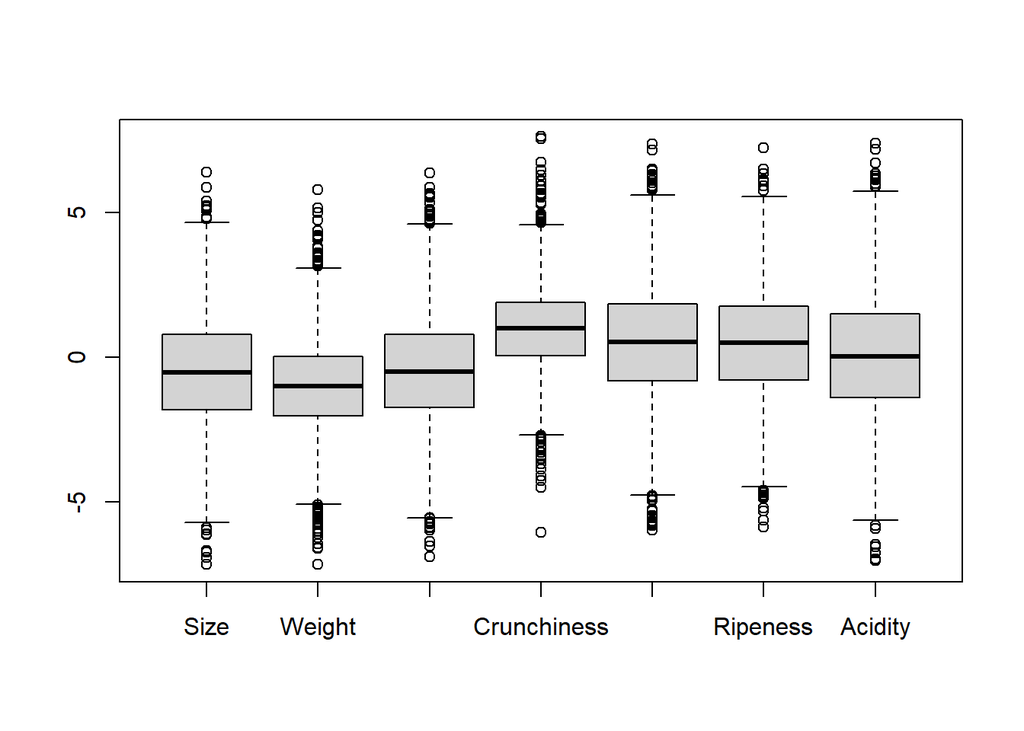

```r
boxplot(apples[,2:8])
```

## Histograms for Weight:

### Question:What is the distribution of weights among apples in the dataset?

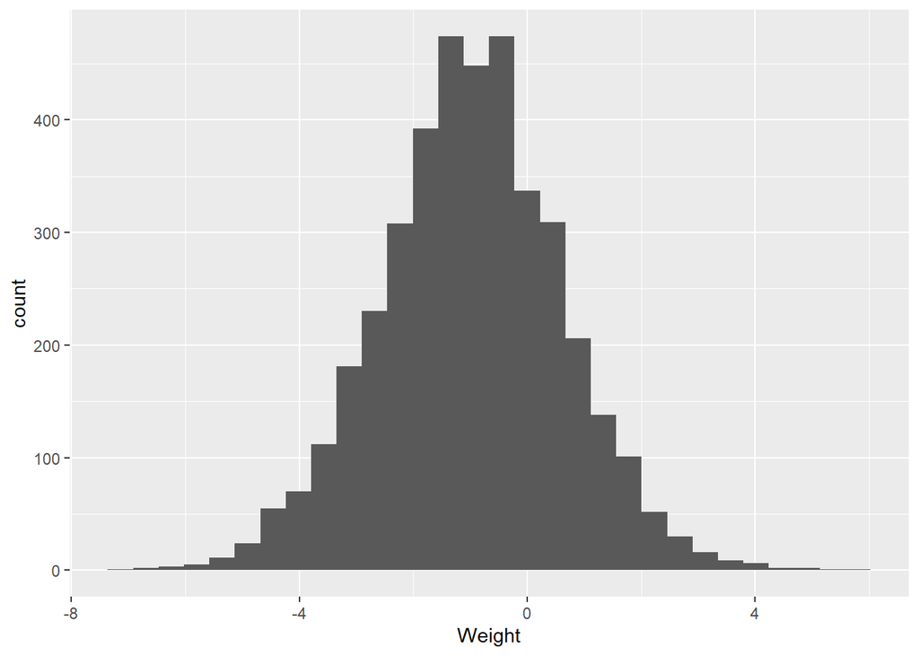

```r
library(ggplot2)
ggplot(apples, aes(Weight))+geom_histogram()
```

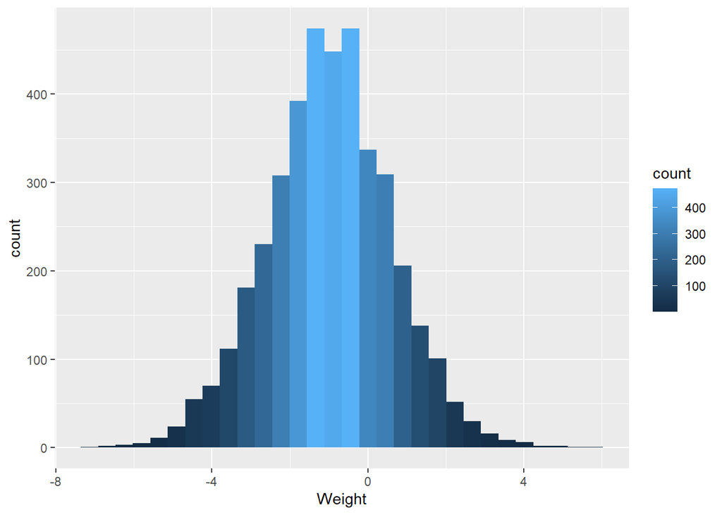

```r
ggplot(apples, aes(Weight))+geom_histogram(aes(fill = after_stat(count)))
```

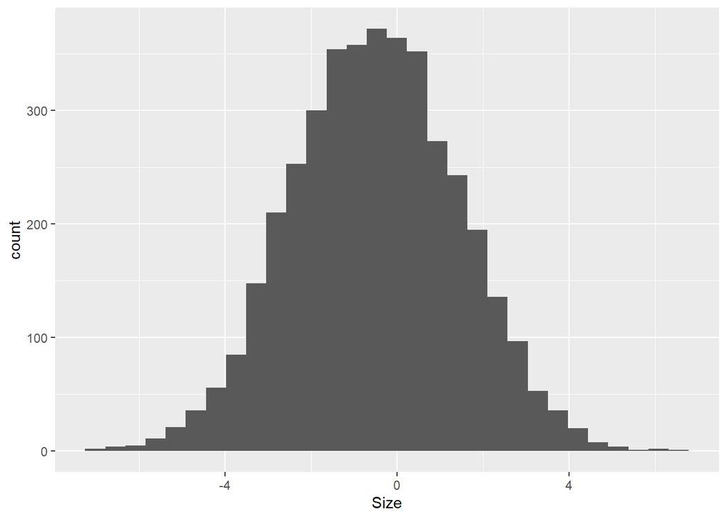

```r
ggplot(apples, aes(Size))+geom_histogram()
```

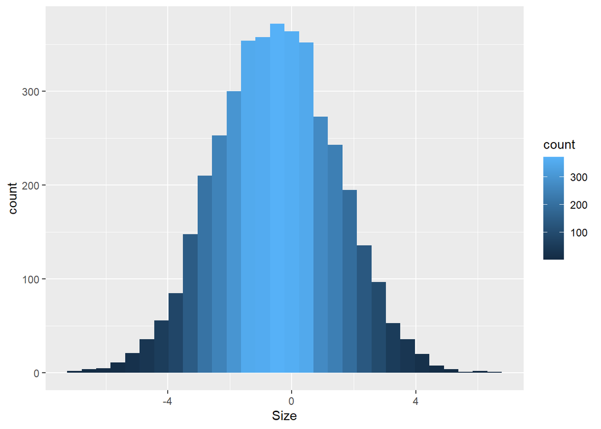

```r
ggplot(apples, aes(Size))+geom_histogram(aes(fill = after_stat(count)))
```

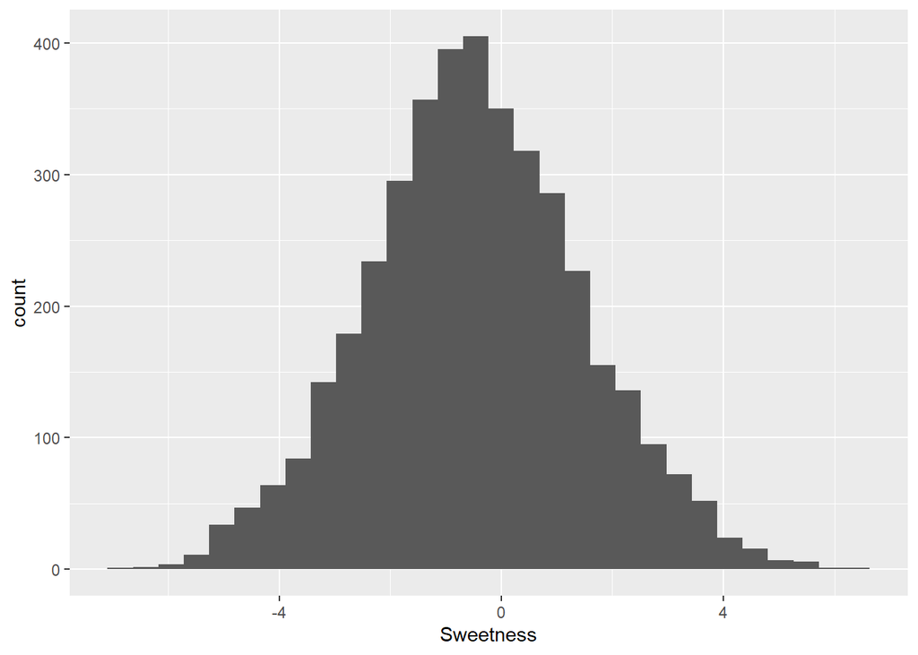

```r
ggplot(apples, aes(Sweetness))+geom_histogram()
```

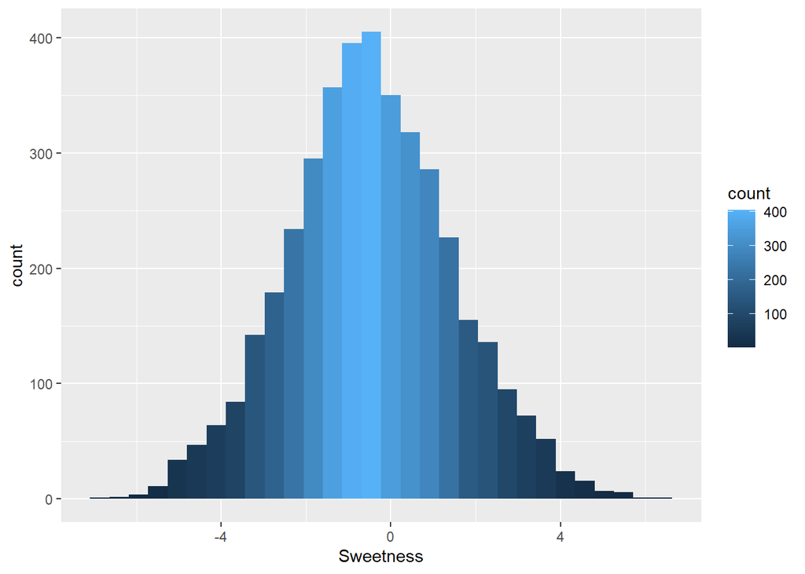

```r
ggplot(apples, aes(Sweetness))+geom_histogram(aes(fill = after_stat(count)))
```

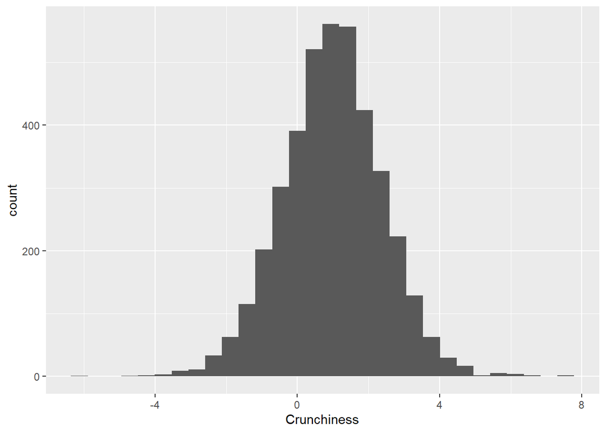

```r
ggplot(apples, aes(Crunchiness))+geom_histogram()
```

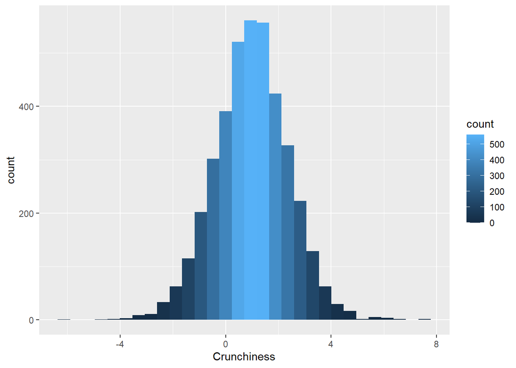

```r
ggplot(apples, aes(Crunchiness))+geom_histogram(aes(fill = after_stat(count)))
```

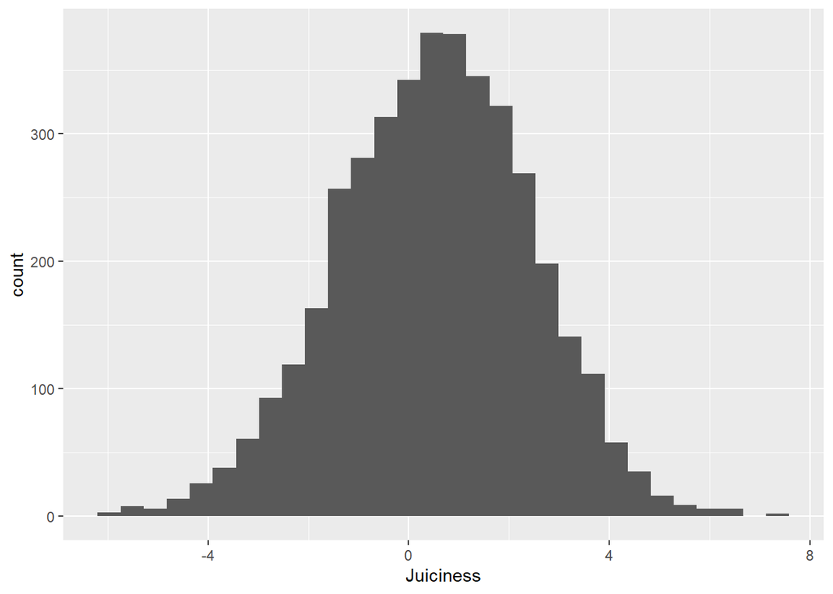

```r
ggplot(apples, aes(Juiciness))+geom_histogram()
```

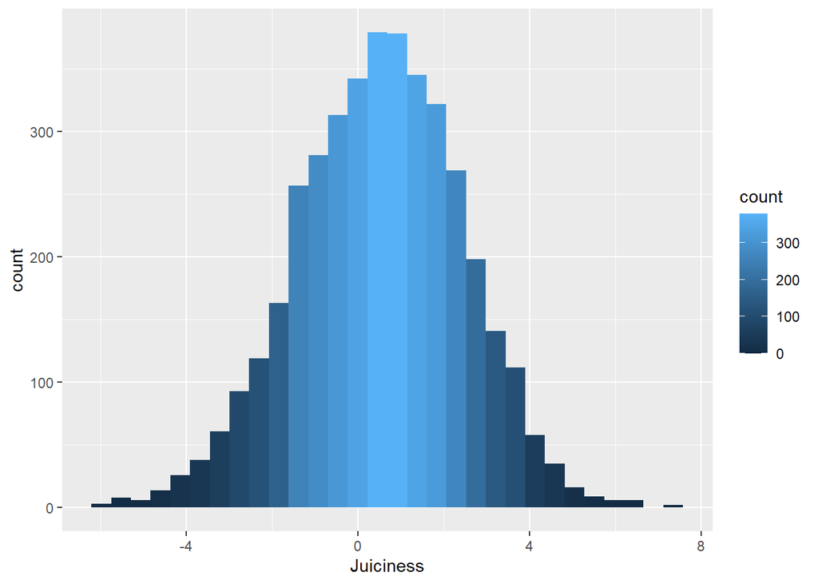

```r
ggplot(apples, aes(Juiciness))+geom_histogram(aes(fill = after_stat(count)))
```

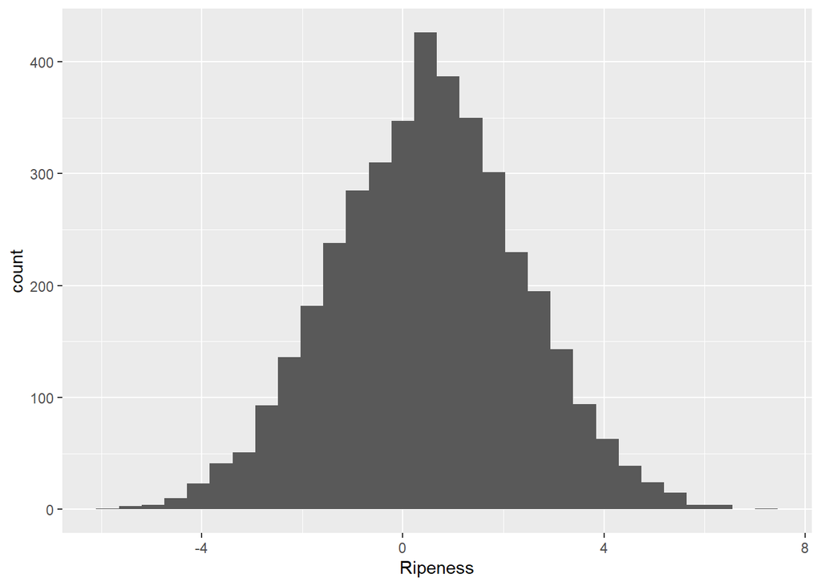

```r
ggplot(apples, aes(Ripeness))+geom_histogram()
```

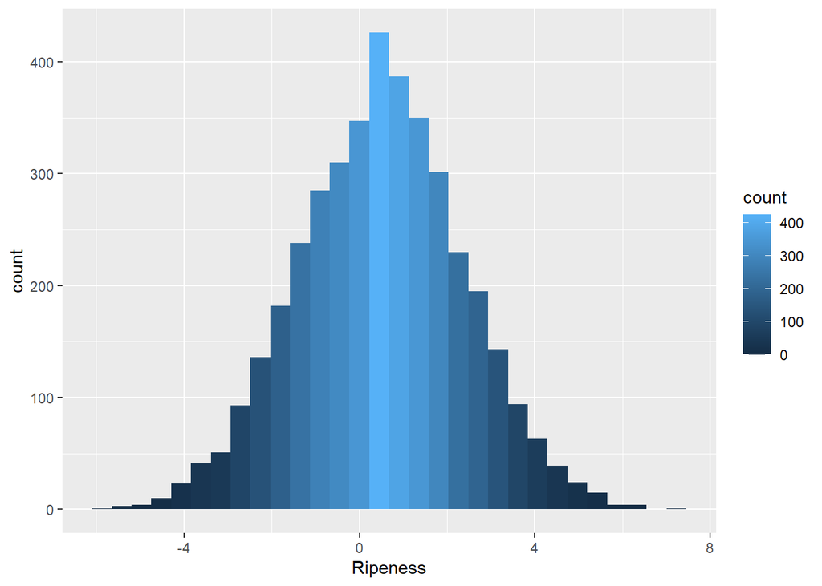

```r
ggplot(apples, aes(Ripeness))+geom_histogram(aes(fill = after_stat(count)))
```

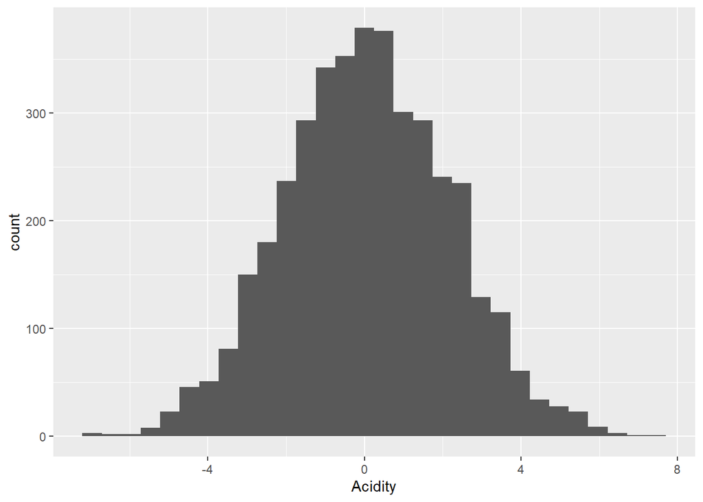

```r
ggplot(apples, aes(Acidity))+geom_histogram()
```

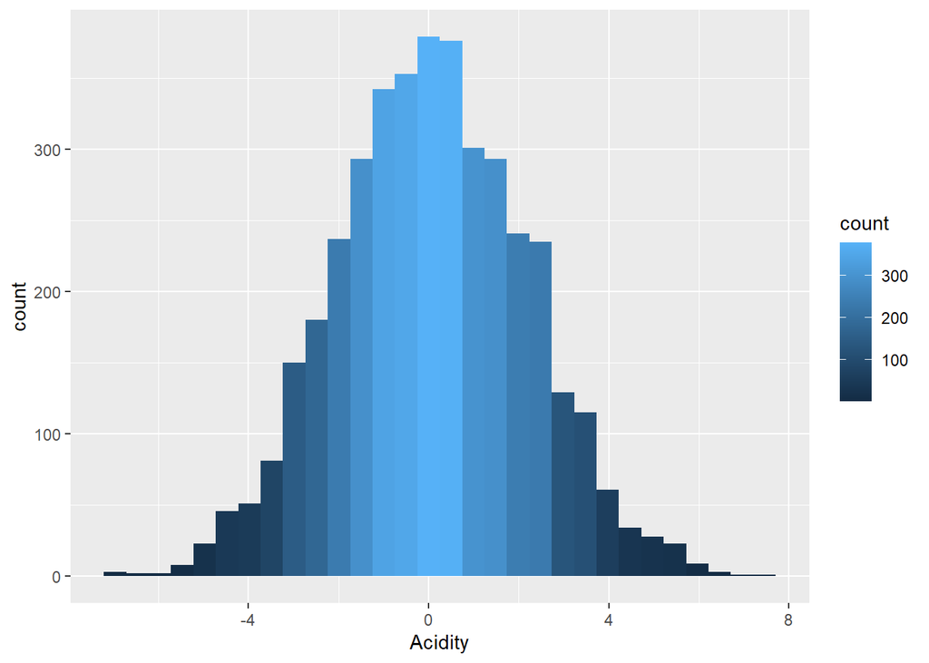

```r
ggplot(apples, aes(Acidity))+geom_histogram(aes(fill = after_stat(count)))
```

##### Inference: Created histograms to visualize the distribution of weights.The histograms show the frequency distribution of weights. We can observe the central tendency and spread of weights in the dataset. We can observe from the graphs that Ripeness and crunchiness are more normally distributes than the others. These histograms provide insights into the distribution patterns of each attribute, helping to understand the range and concentration of values.

## Pairs Plot:

### Question: What are the pairwise relationships and distributions between different attributes?

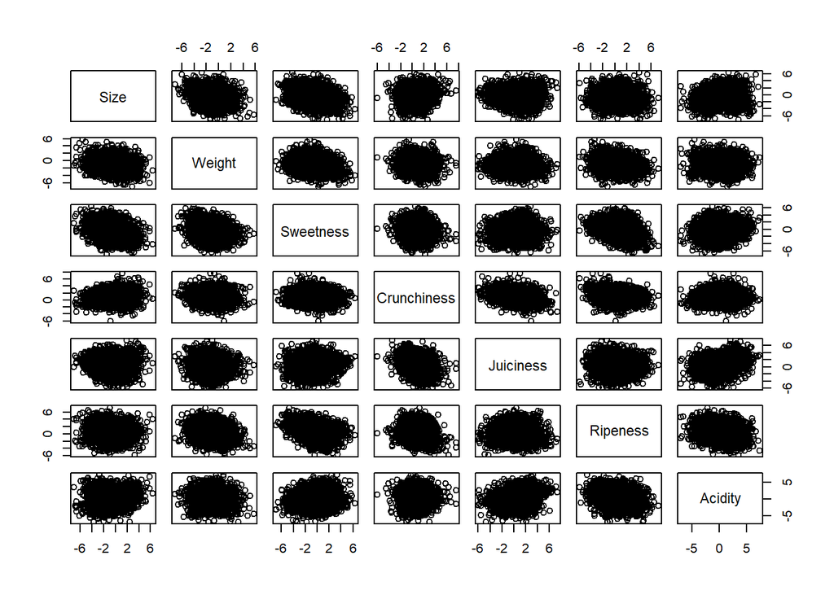

```r
pairs(apples[,2:8])
```

##### Inference: Utilized the `pairs` function to create a matrix of scatterplots for pairwise attribute comparisons. The pairs plot allows you to identify patterns, correlations, and potential clusters in the data. It’s useful for exploring relationships between multiple attributes simultaneously. In the visual we created above since there are too many data points, it is all looking clustered and is difficult to analyze from the same.

## Scatter Plot Matrix with GGally:

### Question: How do Size, Sweetness, Juiciness, Weight, Crunchiness, and Ripeness collectively relate to apple quality?

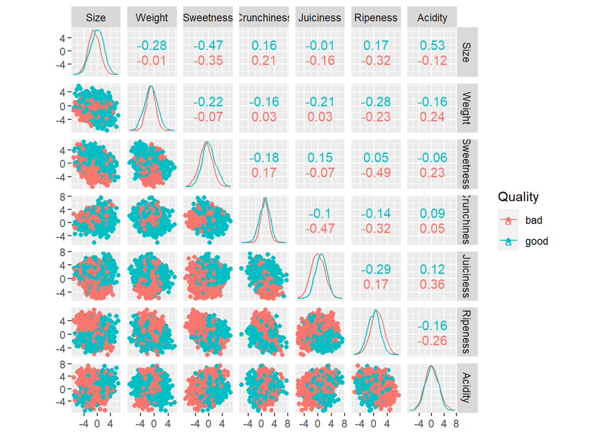

```r
library(GGally)
ggscatmat(apples, columns=2:8, color="Quality")
```

##### Inference: Constructed a scatter plot matrix using `ggscatmat` from GGally, color-coded by apple quality. The scatter plot matrix helps visualize the relationships between pairs of attributes, considering the apple quality as a categorical variable. It’s useful for identifying patterns and trends.In this graph it is a little better to analyze because it is color coded and also has a histogram representation. It also includes the exact number of the correlation between two attributes. With this we can get to know the trends and patterns of attributes which are affecting the apple quality. We can see that the combination of size and crunchiness have the most normally distributed graph and also a greater number of good quality apples.

## Custom Scatter Plot Matrix with ggplot2 and GGally:

### Question: How do certain attribute combinations relate to apple quality?

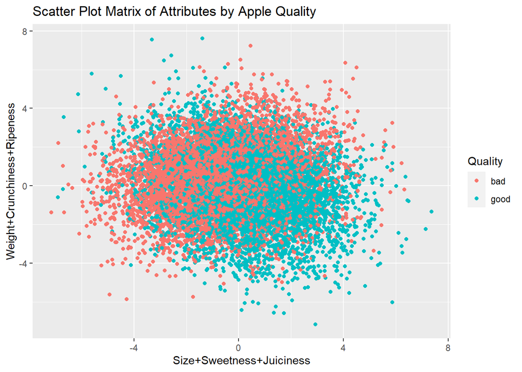

```r
library(ggplot2)
library(GGally)

# Scatter plot matrix
scatter_matrix <- ggplot(apples, aes(color = Quality)) +
  geom_point(aes(x = Size, y = Weight)) +
  geom_point(aes(x = Sweetness, y = Crunchiness)) +
  geom_point(aes(x = Juiciness, y = Ripeness)) +

  labs(title = "Scatter Plot Matrix of Attributes by Apple Quality",
       x = "Size+Sweetness+Juiciness",
       y = "Weight+Crunchiness+Ripeness")

print(scatter_matrix)
```

### Question: What is the correlation between different attributes (Size, Weight, Sweetness, Crunchiness, Juiciness, Ripeness, Acidity) in the apples dataset?

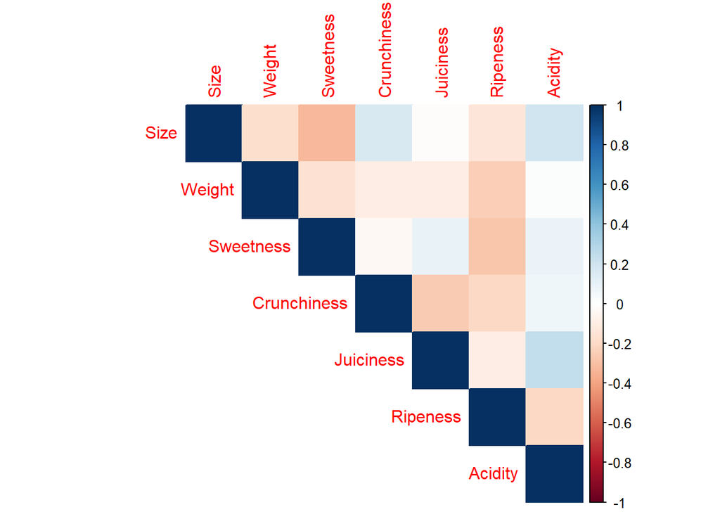

```r
library(corrplot)
corrplot(cor(apples[,2:8]), type = "upper", method = "color")
```